# Análisis de correspondencias múltiples objetivo–subjetivo

- Mostrar todo el código
- Ocultar todo el código
- Ver el código fuente

Posiciones económicas, experiencias de inseguridad y configuraciones sociales

Autor/a

Gonzalo Torres

Fecha de publicación

23 de julio de 2026

# 1 Propósito

Este documento construye un análisis de correspondencias múltiples orientado a representar conjuntamente dimensiones objetivas y subjetivas de la seguridad económica.

El espacio del ACM se construye mediante seis variables activas.

Variables objetivas:

- posición de ingreso;
- nivel educacional;
- tenencia de vivienda.

Variables subjetivas:

- dificultad para llegar a fin de mes;
- fragilidad ante una pérdida de ingresos;
- desprotección financiera frente a problemas de salud.

Las posiciones sociales se incorporan posteriormente sin intervenir en la construcción de los ejes. Se examinan:

- grupos combinados de género y edad;
- género y estructura parental entre hogares con menores;
- condición de actividad;
- presencia de deuda;
- disponibilidad de apoyo monetario;
- disminución reciente de ingresos.

El objetivo no es reducir todas las desigualdades a una única escala, sino examinar:

- convergencias entre posición objetiva y experiencia subjetiva;
- desacoples entre recursos y percepciones de seguridad;
- configuraciones sociales asociadas con distintas zonas del espacio.

# 2 Configuración del entorno

## 2.1 Paquetes

**Mostrar código**

```r
paquetes_necesarios <- c(
  "dplyr",
  "tidyr",
  "purrr",
  "stringr",
  "forcats",
  "tibble",
  "readr",
  "openxlsx",
  "here",
  "knitr",
  "ggplot2",
  "ggrepel",
  "FactoMineR",
  "scales"
)

options(
  repos = c(
    CRAN = "https://cloud.r-project.org"
  ),
  dplyr.summarise.inform = FALSE,
  scipen = 999
)

paquetes_faltantes <- paquetes_necesarios[
  !paquetes_necesarios %in%
    rownames(
      installed.packages()
    )
]

if (length(paquetes_faltantes) > 0) {

  install.packages(
    paquetes_faltantes,
    repos = "https://cloud.r-project.org"
  )
}

invisible(
  lapply(
    paquetes_necesarios,
    library,
    character.only = TRUE
  )
)
```

## 2.2 Carpetas del proyecto

**Mostrar código**

```r
ruta_datos_derivados <- here::here(
  "Datos",
  "EBS",
  "derivados"
)

ruta_salidas <- here::here(
  "outputs",
  "05_acm_objetivo_subjetivo"
)

ruta_tablas <- file.path(
  ruta_salidas,
  "tablas"
)

ruta_figuras <- file.path(
  ruta_salidas,
  "figuras"
)

ruta_objetos <- file.path(
  ruta_salidas,
  "objetos"
)

dir.create(
  ruta_tablas,
  recursive = TRUE,
  showWarnings = FALSE
)

dir.create(
  ruta_figuras,
  recursive = TRUE,
  showWarnings = FALSE
)

dir.create(
  ruta_objetos,
  recursive = TRUE,
  showWarnings = FALSE
)

cat(
  "Directorio del proyecto:",
  normalizePath(
    here::here(),
    winslash = "/",
    mustWork = FALSE
  ),
  "\n"
)
```

```
Directorio del proyecto: C:/Users/PC/OneDrive/Postgrados/OBDE/Taller Med Obj Subj
```

# 3 Carga de la base analítica

## 3.1 Archivo requerido

**Mostrar código**

```r
archivo_base <- file.path(
  ruta_datos_derivados,
  "01_ebs_vida_laboral_genero.rds"
)

if (!file.exists(archivo_base)) {

  stop(
    paste0(
      "No se encontró la base derivada:\n",
      archivo_base,
      "\n\nRenderice primero analisis/01_preparacion_base.qmd."
    )
  )
}
```

**Mostrar código**

```r
base_origen <- readRDS(
  archivo_base
)

cat(
  "Casos en la base de origen:",
  nrow(
    base_origen
  ),
  "\n"
)
```

```
Casos en la base de origen: 7612
```

**Mostrar código**

```r
cat(
  "Variables en la base de origen:",
  ncol(
    base_origen
  ),
  "\n"
)
```

```
Variables en la base de origen: 46
```

# 4 Verificación de variables

## 4.1 Variables activas

**Mostrar código**

```r
variables_objetivas <- c(
  "posicion_ingreso_3",
  "nivel_educacional_3",
  "tenencia_vivienda_3"
)

variables_subjetivas <- c(
  "inseguridad_fin_mes",
  "inseguridad_reservas",
  "inseguridad_salud"
)

variables_activas <- c(
  variables_objetivas,
  variables_subjetivas
)
```

## 4.2 Variables complementarias

**Mostrar código**

```r
variables_complementarias <- c(
  "grupo_sexo_edad",
  "grupo_genero_estructura_menores",
  "grupo_genero_tipo_hogar_menores",
  "condicion_actividad",
  "presencia_deuda",
  "inseguridad_apoyo",
  "disminucion_ingreso"
)
```

## 4.3 Variables técnicas

**Mostrar código**

```r
variables_tecnicas <- c(
  "identificador_persona",
  "ponderador",
  "genero",
  "tramo_edad",
  "presencia_menores_18",
  "quintil_ingreso_etiqueta",
  "educacion_etiqueta",
  "tenencia_vivienda_etiqueta"
)
```

**Mostrar código**

```r
variables_requeridas <- unique(
  c(
    variables_activas,
    variables_complementarias,
    variables_tecnicas
  )
)

variables_faltantes <- setdiff(
  variables_requeridas,
  names(
    base_origen
  )
)

if (length(variables_faltantes) > 0) {

  stop(
    paste0(
      "Faltan variables necesarias para el ACM:\n",
      paste(
        variables_faltantes,
        collapse = ", "
      )
    )
  )
}
```

# 5 Preparación de las modalidades activas

## 5.1 Función para crear factores binarios

**Mostrar código**

```r
crear_factor_binario <- function(
    x,
    etiqueta_favorable,
    etiqueta_desfavorable
) {

  salida <- dplyr::case_when(
    x == 0 ~ etiqueta_favorable,
    x == 1 ~ etiqueta_desfavorable,
    TRUE ~ NA_character_
  )

  factor(
    salida,
    levels = c(
      etiqueta_favorable,
      etiqueta_desfavorable
    )
  )
}

normalizar_texto <- function(
    x
) {

  x |>
    as.character() |>
    stringr::str_to_lower() |>
    stringr::str_replace_all(
      "[áàäâ]",
      "a"
    ) |>
    stringr::str_replace_all(
      "[éèëê]",
      "e"
    ) |>
    stringr::str_replace_all(
      "[íìïî]",
      "i"
    ) |>
    stringr::str_replace_all(
      "[óòöô]",
      "o"
    ) |>
    stringr::str_replace_all(
      "[úùüû]",
      "u"
    ) |>
    stringr::str_replace_all(
      "ñ",
      "n"
    ) |>
    stringr::str_squish()
}
```

## 5.2 Construcción de la base para el ACM

**Mostrar código**

```r
base_preparada <- base_origen |>
  dplyr::mutate(
    quintil_texto = normalizar_texto(
      quintil_ingreso_etiqueta
    ),

    educacion_texto = normalizar_texto(
      educacion_etiqueta
    ),

    tenencia_texto = normalizar_texto(
      tenencia_vivienda_etiqueta
    )
  ) |>
  dplyr::transmute(
    identificador_persona = as.character(
      identificador_persona
    ),

    ponderador = as.numeric(
      ponderador
    ),

    posicion_ingreso = dplyr::case_when(
      stringr::str_detect(
        quintil_texto,
        "quintil\\s*(iv|v)\\b|(iv|v)\\s*quintil|cuarto|quinto|^4\\.?|^5\\.?"
      ) ~ "Ingresos altos",

      stringr::str_detect(
        quintil_texto,
        "quintil\\s*iii\\b|iii\\s*quintil|tercer|^3\\.?"
      ) ~ "Ingresos medios",

      stringr::str_detect(
        quintil_texto,
        "quintil\\s*(i|ii)\\b|(i|ii)\\s*quintil|primer|segundo|^1\\.?|^2\\.?"
      ) ~ "Ingresos bajos",

      TRUE ~ NA_character_
    ),

    posicion_ingreso = factor(
      posicion_ingreso,
      levels = c(
        "Ingresos bajos",
        "Ingresos medios",
        "Ingresos altos"
      )
    ),

    nivel_educacional = dplyr::case_when(
      stringr::str_detect(
        educacion_texto,
        "superior"
      ) ~ "Educación superior",

      stringr::str_detect(
        educacion_texto,
        "media"
      ) ~ "Educación media",

      stringr::str_detect(
        educacion_texto,
        "basica|sin educacion|ningun nivel"
      ) ~ "Educación básica",

      TRUE ~ NA_character_
    ),

    nivel_educacional = factor(
      nivel_educacional,
      levels = c(
        "Educación básica",
        "Educación media",
        "Educación superior"
      )
    ),

    tenencia_vivienda = dplyr::case_when(
      stringr::str_detect(
        tenencia_texto,
        "propia"
      ) ~ "Vivienda propia",

      stringr::str_detect(
        tenencia_texto,
        "arrend"
      ) ~ "Vivienda arrendada",

      stringr::str_detect(
        tenencia_texto,
        "cedida|poseedor|ocupante|usufructo|otra"
      ) ~ "Vivienda cedida u otra",

      TRUE ~ NA_character_
    ),

    tenencia_vivienda = factor(
      tenencia_vivienda,
      levels = c(
        "Vivienda propia",
        "Vivienda arrendada",
        "Vivienda cedida u otra"
      )
    ),

    fin_de_mes = crear_factor_binario(
      inseguridad_fin_mes,
      etiqueta_favorable =
        "Facilidad para llegar a fin de mes",
      etiqueta_desfavorable =
        "Dificultad para llegar a fin de mes"
    ),

    fragilidad_ingresos = crear_factor_binario(
      inseguridad_reservas,
      etiqueta_favorable =
        "Menor fragilidad ante pérdida de ingresos",
      etiqueta_desfavorable =
        "Fragilidad intensa ante pérdida de ingresos"
    ),

    proteccion_salud = crear_factor_binario(
      inseguridad_salud,
      etiqueta_favorable =
        "Protección financiera en salud",
      etiqueta_desfavorable =
        "Desprotección financiera en salud"
    ),

    grupo_sexo_edad = factor(
      as.character(
        grupo_sexo_edad
      ),
      levels = c(
        "Mujeres · 18–29",
        "Hombres · 18–29",
        "Mujeres · 30–44",
        "Hombres · 30–44",
        "Mujeres · 45–59",
        "Hombres · 45–59"
      )
    ),

    grupo_genero_estructura_menores = factor(
      as.character(
        grupo_genero_estructura_menores
      ),
      levels = c(
        "Mujeres · hogar biparental",
        "Mujeres · hogar monoparental",
        "Hombres · hogar biparental",
        "Hombres · hogar monoparental"
      )
    ),

    grupo_genero_tipo_hogar_menores = factor(
      as.character(
        grupo_genero_tipo_hogar_menores
      )
    ),

    condicion_actividad = factor(
      as.character(
        condicion_actividad
      ),
      levels = c(
        "Ocupada/o",
        "Desocupada/o",
        "Fuera de la fuerza de trabajo"
      )
    ),

    deuda = dplyr::case_when(
      presencia_deuda == 0L ~ "Sin deuda",
      presencia_deuda == 1L ~ "Con deuda",
      TRUE ~ NA_character_
    ),

    deuda = factor(
      deuda,
      levels = c(
        "Sin deuda",
        "Con deuda"
      )
    ),

    apoyo_monetario = dplyr::case_when(
      inseguridad_apoyo == 0L ~
        "Cuenta con apoyo monetario",

      inseguridad_apoyo == 1L ~
        "Sin apoyo monetario",

      TRUE ~ NA_character_
    ),

    apoyo_monetario = factor(
      apoyo_monetario,
      levels = c(
        "Cuenta con apoyo monetario",
        "Sin apoyo monetario"
      )
    ),

    cambio_ingreso = dplyr::case_when(
      disminucion_ingreso == 0L ~
        "Ingreso estable o aumentado",

      disminucion_ingreso == 1L ~
        "Ingreso disminuyó",

      TRUE ~ NA_character_
    ),

    cambio_ingreso = factor(
      cambio_ingreso,
      levels = c(
        "Ingreso estable o aumentado",
        "Ingreso disminuyó"
      )
    ),

    genero = factor(
      as.character(
        genero
      ),
      levels = c(
        "Mujeres",
        "Hombres"
      )
    ),

    tramo_edad = factor(
      as.character(
        tramo_edad
      ),
      levels = c(
        "18 a 29 años",
        "30 a 44 años",
        "45 a 59 años"
      )
    ),

    presencia_menores_18 =
      presencia_menores_18
  )
```

## 5.3 Nombres finales de variables activas

**Mostrar código**

```r
variables_activas_acm <- c(
  "posicion_ingreso",
  "nivel_educacional",
  "tenencia_vivienda",
  "fin_de_mes",
  "fragilidad_ingresos",
  "proteccion_salud"
)
```

# 6 Auditoría de cobertura

## 6.1 Función de cobertura

**Mostrar código**

```r
resumir_cobertura <- function(
    datos,
    variables
) {

  purrr::map_dfr(
    variables,
    function(
        variable
    ) {

      n_total <- nrow(
        datos
      )

      n_valido <- sum(
        !is.na(
          datos[[variable]]
        )
      )

      tibble::tibble(
        variable = variable,
        n_total = n_total,
        n_valido = n_valido,
        porcentaje_valido = 100 *
          n_valido /
          n_total
      )
    }
  )
}
```

**Mostrar código**

```r
tabla_cobertura_activas <- resumir_cobertura(
  base_preparada,
  variables_activas_acm
)

knitr::kable(
  tabla_cobertura_activas |>
    dplyr::mutate(
      porcentaje_valido = round(
        porcentaje_valido,
        1
      )
    ),
  caption = "Cobertura de las variables activas"
)
```

Cobertura de las variables activas

| variable | n_total | n_valido | porcentaje_valido |
| --- | --- | --- | --- |
| posicion_ingreso | 7612 | 7612 | 100.0 |
| nivel_educacional | 7612 | 7541 | 99.1 |
| tenencia_vivienda | 7612 | 7612 | 100.0 |
| fin_de_mes | 7612 | 7604 | 99.9 |
| fragilidad_ingresos | 7612 | 7592 | 99.7 |
| proteccion_salud | 7612 | 7595 | 99.8 |

## 6.2 Casos completos

**Mostrar código**

```r
tabla_diagnostico_modalidades_activas <-
  purrr::map_dfr(
    variables_activas_acm,
    function(
        variable
    ) {

      tibble::tibble(
        variable = variable,

        n_valido = sum(
          !is.na(
            base_preparada[[variable]]
          )
        ),

        porcentaje_valido = 100 *
          mean(
            !is.na(
              base_preparada[[variable]]
            )
          ),

        numero_modalidades = dplyr::n_distinct(
          base_preparada[[variable]],
          na.rm = TRUE
        ),

        modalidades = paste(
          unique(
            stats::na.omit(
              as.character(
                base_preparada[[variable]]
              )
            )
          ),
          collapse = " | "
        )
      )
    }
  )

knitr::kable(
  tabla_diagnostico_modalidades_activas |>
    dplyr::mutate(
      porcentaje_valido = round(
        porcentaje_valido,
        1
      )
    ),
  caption = "Diagnóstico previo de las variables activas"
)
```

Diagnóstico previo de las variables activas

| variable | n_valido | porcentaje_valido | numero_modalidades | modalidades |
| --- | --- | --- | --- | --- |
| posicion_ingreso | 7612 | 100.0 | 3 | Ingresos altos \| Ingresos bajos \| Ingresos medios |
| nivel_educacional | 7541 | 99.1 | 3 | Educación media \| Educación superior \| Educación básica |
| tenencia_vivienda | 7612 | 100.0 | 3 | Vivienda propia \| Vivienda cedida u otra \| Vivienda arrendada |
| fin_de_mes | 7604 | 99.9 | 2 | Facilidad para llegar a fin de mes \| Dificultad para llegar a fin de mes |
| fragilidad_ingresos | 7592 | 99.7 | 2 | Fragilidad intensa ante pérdida de ingresos \| Menor fragilidad ante pérdida de ingresos |
| proteccion_salud | 7595 | 99.8 | 2 | Desprotección financiera en salud \| Protección financiera en salud |

**Mostrar código**

```r
indicador_casos_completos <- stats::complete.cases(
  base_preparada[
    variables_activas_acm
  ]
)

tabla_muestra_acm <- tibble::tibble(
  indicador = c(
    "Casos en la base de origen",
    "Casos completos en las variables activas",
    "Porcentaje retenido"
  ),

  valor = c(
    nrow(
      base_preparada
    ),

    sum(
      indicador_casos_completos
    ),

    100 *
      mean(
        indicador_casos_completos
      )
  )
)

knitr::kable(
  tabla_muestra_acm |>
    dplyr::mutate(
      valor = round(
        valor,
        1
      )
    ),
  caption = "Muestra analítica del ACM objetivo–subjetivo"
)
```

Muestra analítica del ACM objetivo–subjetivo

| indicador | valor |
| --- | --- |
| Casos en la base de origen | 7612.0 |
| Casos completos en las variables activas | 7500.0 |
| Porcentaje retenido | 98.5 |

# 7 Selección de la muestra analítica

**Mostrar código**

```r
base_acm <- base_preparada |>
  dplyr::mutate(
    caso_completo_acm =
      stats::complete.cases(
        dplyr::pick(
          dplyr::all_of(
            variables_activas_acm
          )
        )
      )
  ) |>
  dplyr::filter(
    caso_completo_acm,
    !is.na(
      ponderador
    ),
    ponderador > 0
  ) |>
  dplyr::select(
    -caso_completo_acm
  ) |>
  droplevels()
```

**Mostrar código**

```r
if (nrow(base_acm) == 0) {

  stop(
    "No quedaron casos válidos para estimar el ACM."
  )
}
```

**Mostrar código**

```r
resumen_muestra_acm <- tibble::tibble(
  indicador = c(
    "Casos en base de origen",
    "Casos completos con ponderador válido",
    "Porcentaje retenido",
    "Suma de ponderadores",
    "Tamaño efectivo aproximado"
  ),

  valor = c(
    nrow(
      base_preparada
    ),

    nrow(
      base_acm
    ),

    100 *
      nrow(
        base_acm
      ) /
      nrow(
        base_preparada
      ),

    sum(
      base_acm$ponderador,
      na.rm = TRUE
    ),

    sum(
      base_acm$ponderador,
      na.rm = TRUE
    )^2 /
      sum(
        base_acm$ponderador^2,
        na.rm = TRUE
      )
  )
)

knitr::kable(
  resumen_muestra_acm |>
    dplyr::mutate(
      valor = round(
        valor,
        1
      )
    ),
  caption = "Resumen de la muestra utilizada en el ACM"
)
```

Resumen de la muestra utilizada en el ACM

| indicador | valor |
| --- | --- |
| Casos en base de origen | 7612.0 |
| Casos completos con ponderador válido | 7500.0 |
| Porcentaje retenido | 98.5 |
| Suma de ponderadores | 11267707.0 |
| Tamaño efectivo aproximado | 3798.7 |

# 8 Distribución de las modalidades activas

**Mostrar código**

```r
tabla_distribucion_modalidades <- purrr::map_dfr(
  variables_activas_acm,
  function(
      variable
  ) {

    base_acm |>
      dplyr::count(
        modalidad = .data[[variable]],
        wt = ponderador,
        name = "frecuencia_ponderada",
        .drop = FALSE
      ) |>
      dplyr::mutate(
        variable = variable,
        porcentaje_ponderado = 100 *
          frecuencia_ponderada /
          sum(
            frecuencia_ponderada
          ),
        .before = 1
      )
  }
)
```

**Mostrar código**

```r
knitr::kable(
  tabla_distribucion_modalidades |>
    dplyr::mutate(
      frecuencia_ponderada = round(
        frecuencia_ponderada
      ),
      porcentaje_ponderado = round(
        porcentaje_ponderado,
        1
      )
    ),
  caption = "Distribución ponderada de las modalidades activas"
)
```

Distribución ponderada de las modalidades activas

| variable | porcentaje_ponderado | modalidad | frecuencia_ponderada |
| --- | --- | --- | --- |
| posicion_ingreso | 41.0 | Ingresos bajos | 4623072 |
| posicion_ingreso | 21.3 | Ingresos medios | 2402002 |
| posicion_ingreso | 37.7 | Ingresos altos | 4242633 |
| nivel_educacional | 9.7 | Educación básica | 1089388 |
| nivel_educacional | 42.9 | Educación media | 4837114 |
| nivel_educacional | 47.4 | Educación superior | 5341205 |
| tenencia_vivienda | 58.8 | Vivienda propia | 6629509 |
| tenencia_vivienda | 25.7 | Vivienda arrendada | 2897589 |
| tenencia_vivienda | 15.4 | Vivienda cedida u otra | 1740609 |
| fin_de_mes | 18.4 | Facilidad para llegar a fin de mes | 2077953 |
| fin_de_mes | 81.6 | Dificultad para llegar a fin de mes | 9189754 |
| fragilidad_ingresos | 26.2 | Menor fragilidad ante pérdida de ingresos | 2950679 |
| fragilidad_ingresos | 73.8 | Fragilidad intensa ante pérdida de ingresos | 8317028 |
| proteccion_salud | 21.7 | Protección financiera en salud | 2447807 |
| proteccion_salud | 78.3 | Desprotección financiera en salud | 8819900 |

# 9 Estimación del ACM

## 9.1 Matriz activa

**Mostrar código**

```r
datos_activos_acm <- base_acm |>
  dplyr::select(
    dplyr::all_of(
      variables_activas_acm
    )
  ) |>
  as.data.frame()
```

## 9.2 Modelo

**Mostrar código**

```r
resultado_acm <- FactoMineR::MCA(
  datos_activos_acm,
  ncp = 10,
  row.w = base_acm$ponderador,
  graph = FALSE
)
```

**Mostrar código**

```r
saveRDS(
  resultado_acm,
  file.path(
    ruta_objetos,
    "05_resultado_acm_objetivo_subjetivo.rds"
  )
)
```

# 10 Inercia

## 10.1 Tabla de valores propios

**Mostrar código**

```r
tabla_inercia <- as.data.frame(
  resultado_acm$eig
)

tabla_inercia$dimension <- rownames(
  tabla_inercia
)

rownames(
  tabla_inercia
) <- NULL

tabla_inercia <- tabla_inercia[
  ,
  c(
    "dimension",
    names(
      tabla_inercia
    )[1:3]
  )
]

names(
  tabla_inercia
) <- c(
  "dimension",
  "valor_propio",
  "porcentaje_inercia",
  "porcentaje_acumulado"
)

tabla_inercia <- tibble::as_tibble(
  tabla_inercia
)
```

**Mostrar código**

```r
knitr::kable(
  tabla_inercia |>
    dplyr::mutate(
      valor_propio = round(
        valor_propio,
        4
      ),

      porcentaje_inercia = round(
        porcentaje_inercia,
        1
      ),

      porcentaje_acumulado = round(
        porcentaje_acumulado,
        1
      )
    ),
  caption = "Valores propios e inercia del ACM objetivo–subjetivo"
)
```

Valores propios e inercia del ACM objetivo–subjetivo

| dimension | valor_propio | porcentaje_inercia | porcentaje_acumulado |
| --- | --- | --- | --- |
| dim 1 | 0.3264 | 21.8 | 21.8 |
| dim 2 | 0.2009 | 13.4 | 35.2 |
| dim 3 | 0.1735 | 11.6 | 46.7 |
| dim 4 | 0.1681 | 11.2 | 57.9 |
| dim 5 | 0.1577 | 10.5 | 68.4 |
| dim 6 | 0.1434 | 9.6 | 78.0 |
| dim 7 | 0.1272 | 8.5 | 86.5 |
| dim 8 | 0.1023 | 6.8 | 93.3 |
| dim 9 | 0.1006 | 6.7 | 100.0 |

## 10.2 Figura de inercia

**Mostrar código**

```r
datos_figura_inercia <- tabla_inercia |>
  dplyr::slice_head(
    n = 10
  ) |>
  dplyr::mutate(
    dimension = factor(
      paste0(
        "Dimensión ",
        dplyr::row_number()
      ),
      levels = paste0(
        "Dimensión ",
        seq_len(
          dplyr::n()
        )
      )
    )
  )
```

**Mostrar código**

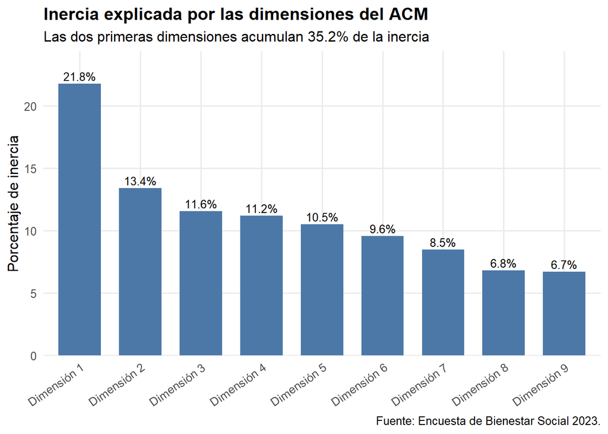

```r
figura_inercia <- ggplot2::ggplot(
  datos_figura_inercia,
  ggplot2::aes(
    x = dimension,
    y = porcentaje_inercia
  )
) +
  ggplot2::geom_col(
    width = 0.7,
    fill = "#4C78A8"
  ) +
  ggplot2::geom_text(
    ggplot2::aes(
      label = paste0(
        round(
          porcentaje_inercia,
          1
        ),
        "%"
      )
    ),
    vjust = -0.35,
    size = 3.4
  ) +
  ggplot2::labs(
    title = "Inercia explicada por las dimensiones del ACM",
    subtitle = paste0(
      "Las dos primeras dimensiones acumulan ",
      round(
        tabla_inercia$porcentaje_acumulado[2],
        1
      ),
      "% de la inercia"
    ),
    x = NULL,
    y = "Porcentaje de inercia",
    caption = "Fuente: Encuesta de Bienestar Social 2023."
  ) +
  ggplot2::scale_y_continuous(
    expand = ggplot2::expansion(
      mult = c(
        0,
        0.12
      )
    )
  ) +
  ggplot2::theme_minimal(
    base_size = 12
  ) +
  ggplot2::theme(
    panel.grid.minor = ggplot2::element_blank(),
    axis.text.x = ggplot2::element_text(
      angle = 35,
      hjust = 1
    ),
    plot.title = ggplot2::element_text(
      face = "bold"
    )
  )

figura_inercia
```

# 11 Coordenadas de las modalidades activas

## 11.1 Extracción

**Mostrar código**

```r
coordenadas_modalidades <- as.data.frame(
  resultado_acm$var$coord
) |>
  tibble::rownames_to_column(
    var = "modalidad_original"
  ) |>
  tibble::as_tibble() |>
  dplyr::rename_with(
    ~ paste0(
      "dimension_",
      seq_along(
        .x
      )
    ),
    .cols = -modalidad_original
  )
```

**Mostrar código**

```r
contribuciones_modalidades <- as.data.frame(
  resultado_acm$var$contrib
) |>
  tibble::rownames_to_column(
    var = "modalidad_original"
  ) |>
  tibble::as_tibble() |>
  dplyr::rename_with(
    ~ paste0(
      "contribucion_",
      seq_along(
        .x
      )
    ),
    .cols = -modalidad_original
  )
```

**Mostrar código**

```r
cos2_modalidades <- as.data.frame(
  resultado_acm$var$cos2
) |>
  tibble::rownames_to_column(
    var = "modalidad_original"
  ) |>
  tibble::as_tibble() |>
  dplyr::rename_with(
    ~ paste0(
      "cos2_",
      seq_along(
        .x
      )
    ),
    .cols = -modalidad_original
  )
```

**Mostrar código**

```r
tabla_modalidades_acm <- coordenadas_modalidades |>
  dplyr::left_join(
    contribuciones_modalidades,
    by = "modalidad_original"
  ) |>
  dplyr::left_join(
    cos2_modalidades,
    by = "modalidad_original"
  )
```

# 12 Diccionario sustantivo de modalidades

**Mostrar código**

```r
tabla_modalidades_acm <- tabla_modalidades_acm |>
  dplyr::mutate(
    modalidad = dplyr::case_when(
      stringr::str_detect(
        modalidad_original,
        "Ingresos bajos"
      ) ~ "Ingresos bajos",

      stringr::str_detect(
        modalidad_original,
        "Ingresos medios"
      ) ~ "Ingresos medios",

      stringr::str_detect(
        modalidad_original,
        "Ingresos altos"
      ) ~ "Ingresos altos",

      stringr::str_detect(
        modalidad_original,
        "Educación básica"
      ) ~ "Educación básica",

      stringr::str_detect(
        modalidad_original,
        "Educación media"
      ) ~ "Educación media",

      stringr::str_detect(
        modalidad_original,
        "Educación superior"
      ) ~ "Educación superior",

      stringr::str_detect(
        modalidad_original,
        "Vivienda propia"
      ) ~ "Vivienda propia",

      stringr::str_detect(
        modalidad_original,
        "Vivienda arrendada"
      ) ~ "Vivienda arrendada",

      stringr::str_detect(
        modalidad_original,
        "Vivienda cedida u otra"
      ) ~ "Vivienda cedida u otra",

      stringr::str_detect(
        modalidad_original,
        "Facilidad para llegar a fin de mes"
      ) ~ "Facilidad para llegar a fin de mes",

      stringr::str_detect(
        modalidad_original,
        "Dificultad para llegar a fin de mes"
      ) ~ "Dificultad para llegar a fin de mes",

      stringr::str_detect(
        modalidad_original,
        "Menor fragilidad"
      ) ~ "Menor fragilidad",

      stringr::str_detect(
        modalidad_original,
        "Fragilidad intensa"
      ) ~ "Fragilidad intensa",

      stringr::str_detect(
        modalidad_original,
        "Protección financiera en salud"
      ) ~ "Protección en salud",

      stringr::str_detect(
        modalidad_original,
        "Desprotección financiera en salud"
      ) ~ "Desprotección en salud",

      TRUE ~ modalidad_original
    ),

    variable_conceptual = dplyr::case_when(
      stringr::str_detect(
        modalidad_original,
        "Ingresos"
      ) ~ "Posición de ingreso",

      stringr::str_detect(
        modalidad_original,
        "Educación"
      ) ~ "Nivel educacional",

      stringr::str_detect(
        modalidad_original,
        "Vivienda"
      ) ~ "Tenencia de vivienda",

      stringr::str_detect(
        modalidad_original,
        "fin de mes"
      ) ~ "Presión económica presente",

      stringr::str_detect(
        modalidad_original,
        "fragilidad"
      ) ~ "Fragilidad ante pérdida de ingresos",

      stringr::str_detect(
        modalidad_original,
        "salud"
      ) ~ "Protección financiera en salud",

      TRUE ~ "No identificada"
    ),

    componente = dplyr::case_when(
      variable_conceptual %in% c(
        "Posición de ingreso",
        "Nivel educacional",
        "Tenencia de vivienda"
      ) ~ "Objetiva",

      variable_conceptual %in% c(
        "Presión económica presente",
        "Fragilidad ante pérdida de ingresos",
        "Protección financiera en salud"
      ) ~ "Subjetiva",

      TRUE ~ "No identificado"
    ),

    cos2_plano_1_2 = cos2_1 + cos2_2,

    contribucion_plano_1_2 =
      contribucion_1 + contribucion_2
  )
```

# 13 Contribuciones de las modalidades

**Mostrar código**

```r
tabla_contribuciones_principales <- tabla_modalidades_acm |>
  dplyr::select(
    componente,
    variable_conceptual,
    modalidad,
    dimension_1,
    dimension_2,
    contribucion_1,
    contribucion_2,
    contribucion_plano_1_2,
    cos2_plano_1_2
  ) |>
  dplyr::arrange(
    dplyr::desc(
      contribucion_plano_1_2
    )
  )
```

**Mostrar código**

```r
knitr::kable(
  tabla_contribuciones_principales |>
    dplyr::mutate(
      dplyr::across(
        where(
          is.numeric
        ),
        ~ round(
          .x,
          3
        )
      )
    ),
  caption = "Coordenadas, contribuciones y calidad de representación de las modalidades"
)
```

Coordenadas, contribuciones y calidad de representación de las modalidades

| componente | variable_conceptual | modalidad | dimension_1 | dimension_2 | contribucion_1 | contribucion_2 | contribucion_plano_1_2 | cos2_plano_1_2 |
| --- | --- | --- | --- | --- | --- | --- | --- | --- |
| Objetiva | Tenencia de vivienda | Vivienda arrendada | 0.255 | -1.152 | 0.854 | 28.310 | 29.163 | 0.482 |
| Subjetiva | Presión económica presente | Facilidad para llegar a fin de mes | 1.390 | 0.723 | 18.203 | 8.002 | 26.205 | 0.555 |
| Subjetiva | Fragilidad ante pérdida de ingresos | Menor fragilidad | 0.983 | 0.687 | 12.929 | 10.256 | 23.185 | 0.511 |
| Subjetiva | Protección financiera en salud | Protección en salud | 1.174 | 0.444 | 15.283 | 3.555 | 18.838 | 0.437 |
| Objetiva | Posición de ingreso | Ingresos altos | 0.807 | -0.418 | 12.523 | 5.445 | 17.968 | 0.499 |
| Objetiva | Posición de ingreso | Ingresos bajos | -0.632 | 0.524 | 8.362 | 9.345 | 17.708 | 0.469 |
| Objetiva | Nivel educacional | Educación superior | 0.592 | -0.419 | 8.479 | 6.894 | 15.373 | 0.474 |
| Objetiva | Nivel educacional | Educación básica | -0.850 | 1.015 | 3.563 | 8.259 | 11.822 | 0.187 |
| No identificado | No identificada | Fragilidad intensa | -0.349 | -0.244 | 4.587 | 3.639 | 8.225 | 0.511 |
| Objetiva | Nivel educacional | Educación media | -0.462 | 0.234 | 4.683 | 1.947 | 6.630 | 0.202 |
| Objetiva | Tenencia de vivienda | Vivienda propia | 0.010 | 0.355 | 0.003 | 6.145 | 6.148 | 0.180 |
| Subjetiva | Presión económica presente | Dificultad para llegar a fin de mes | -0.314 | -0.164 | 4.116 | 1.809 | 5.925 | 0.555 |
| Objetiva | Tenencia de vivienda | Vivienda cedida u otra | -0.464 | 0.566 | 1.695 | 4.109 | 5.803 | 0.098 |
| Subjetiva | Protección financiera en salud | Desprotección en salud | -0.326 | -0.123 | 4.242 | 0.987 | 5.228 | 0.437 |
| Objetiva | Posición de ingreso | Ingresos medios | -0.210 | -0.271 | 0.478 | 1.299 | 1.777 | 0.032 |

# 14 Mapa principal de modalidades activas

## 14.1 Paletas

**Mostrar código**

```r
paleta_variables <- c(
  "Posición de ingreso" = "#1F77B4",
  "Nivel educacional" = "#2CA02C",
  "Tenencia de vivienda" = "#17A2B8",
  "Presión económica presente" = "#D62728",
  "Fragilidad ante pérdida de ingresos" = "#9467BD",
  "Protección financiera en salud" = "#FF7F0E"
)

paleta_componentes <- c(
  "Objetiva" = "#2878B5",
  "Subjetiva" = "#B2477D"
)

paleta_genero <- c(
  "Mujeres" = "#6A3D9A",
  "Hombres" = "#D39B00"
)

paleta_actividad <- c(
  "Ocupada/o" = "#0072B2",
  "Desocupada/o" = "#D55E00",
  "Fuera de la fuerza de trabajo" = "#6E6E6E"
)

paleta_parentalidad <- c(
  "Biparental" = "#2B8CBE",
  "Monoparental" = "#E34A33"
)
```

## 14.2 Figura completa

**Mostrar código**

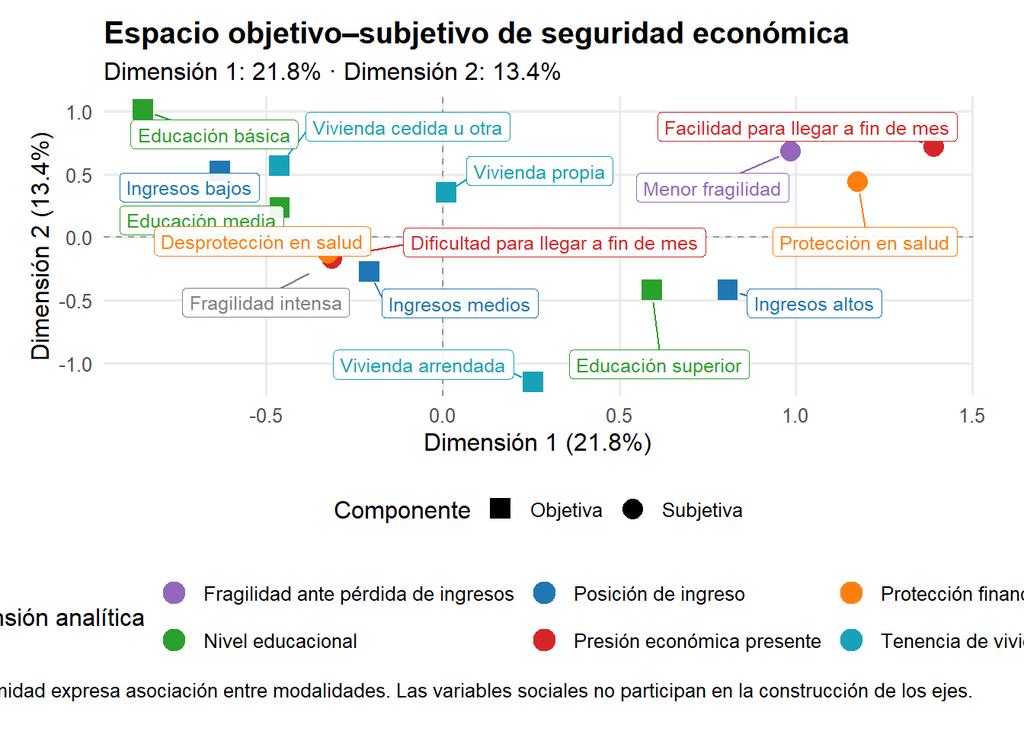

```r
figura_modalidades <- ggplot2::ggplot(
  tabla_modalidades_acm,
  ggplot2::aes(
    x = dimension_1,
    y = dimension_2,
    color = variable_conceptual,
    shape = componente
  )
) +
  ggplot2::geom_hline(
    yintercept = 0,
    linetype = "dashed",
    linewidth = 0.4,
    color = "grey60"
  ) +
  ggplot2::geom_vline(
    xintercept = 0,
    linetype = "dashed",
    linewidth = 0.4,
    color = "grey60"
  ) +
  ggplot2::geom_point(
    size = 4,
    stroke = 1.1
  ) +
  ggrepel::geom_label_repel(
    ggplot2::aes(
      label = modalidad
    ),
    size = 3.35,
    max.overlaps = Inf,
    box.padding = 0.55,
    point.padding = 0.35,
    min.segment.length = 0,
    label.size = 0.15,
    fill = scales::alpha(
      "white",
      0.92
    ),
    show.legend = FALSE
  ) +
  ggplot2::scale_color_manual(
    values = paleta_variables,
    drop = FALSE
  ) +
  ggplot2::scale_shape_manual(
    values = c(
      "Objetiva" = 15,
      "Subjetiva" = 16
    ),
    drop = FALSE
  ) +
  ggplot2::labs(
    title = "Espacio objetivo–subjetivo de seguridad económica",
    subtitle = paste0(
      "Dimensión 1: ",
      round(
        tabla_inercia$porcentaje_inercia[1],
        1
      ),
      "% · Dimensión 2: ",
      round(
        tabla_inercia$porcentaje_inercia[2],
        1
      ),
      "%"
    ),
    x = paste0(
      "Dimensión 1 (",
      round(
        tabla_inercia$porcentaje_inercia[1],
        1
      ),
      "%)"
    ),
    y = paste0(
      "Dimensión 2 (",
      round(
        tabla_inercia$porcentaje_inercia[2],
        1
      ),
      "%)"
    ),
    color = "Dimensión analítica",
    shape = "Componente",
    caption = paste(
      "La proximidad expresa asociación entre modalidades.",
      "Las variables sociales no participan en la construcción de los ejes."
    )
  ) +
  ggplot2::coord_cartesian(
    clip = "off"
  ) +
  ggplot2::theme_minimal(
    base_size = 12
  ) +
  ggplot2::theme(
    panel.grid.minor = ggplot2::element_blank(),
    plot.title = ggplot2::element_text(
      face = "bold",
      size = 15
    ),
    legend.position = "bottom",
    legend.box = "vertical",
    plot.margin = ggplot2::margin(
      10,
      25,
      15,
      15
    )
  )

figura_modalidades
```

# 15 Coordenadas individuales

**Mostrar código**

```r
coordenadas_individuales <- as.data.frame(
  resultado_acm$ind$coord
) |>
  tibble::as_tibble() |>
  dplyr::rename_with(
    ~ paste0(
      "dimension_",
      seq_along(
        .x
      )
    )
  )
```

**Mostrar código**

```r
if (
  nrow(
    coordenadas_individuales
  ) !=
    nrow(
      base_acm
    )
) {

  stop(
    "El número de coordenadas individuales no coincide con la base analítica."
  )
}
```

**Mostrar código**

```r
base_coordenadas_acm <- dplyr::bind_cols(
  base_acm,
  coordenadas_individuales
)
```

# 16 Función para calcular posiciones sociales

**Mostrar código**

```r
media_ponderada_segura <- function(
    x,
    w
) {

  casos_validos <-
    !is.na(
      x
    ) &
    !is.na(
      w
    ) &
    w > 0

  if (!any(casos_validos)) {

    return(
      NA_real_
    )
  }

  stats::weighted.mean(
    x[
      casos_validos
    ],
    w[
      casos_validos
    ]
  )
}
```

**Mostrar código**

```r
calcular_posiciones_grupo <- function(
    datos,
    variable_grupo
) {

  datos |>
    dplyr::filter(
      !is.na(
        .data[[variable_grupo]]
      )
    ) |>
    dplyr::group_by(
      grupo = .data[[variable_grupo]]
    ) |>
    dplyr::summarise(
      dimension_1 = media_ponderada_segura(
        dimension_1,
        ponderador
      ),

      dimension_2 = media_ponderada_segura(
        dimension_2,
        ponderador
      ),

      n = dplyr::n(),

      suma_ponderadores = sum(
        ponderador,
        na.rm = TRUE
      ),

      .groups = "drop"
    ) |>
    dplyr::mutate(
      variable_grupo = variable_grupo,
      .before = 1
    )
}
```

# 17 Posiciones sexo-etarias

**Mostrar código**

```r
tabla_posiciones_sexo_edad <- calcular_posiciones_grupo(
  base_coordenadas_acm,
  "grupo_sexo_edad"
) |>
  dplyr::mutate(
    genero = dplyr::case_when(
      stringr::str_detect(
        grupo,
        "^Mujeres"
      ) ~ "Mujeres",

      stringr::str_detect(
        grupo,
        "^Hombres"
      ) ~ "Hombres",

      TRUE ~ NA_character_
    ),

    genero = factor(
      genero,
      levels = c(
        "Mujeres",
        "Hombres"
      )
    )
  )
```

**Mostrar código**

```r
knitr::kable(
  tabla_posiciones_sexo_edad |>
    dplyr::mutate(
      dplyr::across(
        c(
          dimension_1,
          dimension_2
        ),
        ~ round(
          .x,
          3
        )
      ),

      suma_ponderadores = round(
        suma_ponderadores
      )
    ),
  caption = "Posiciones medias ponderadas de los grupos sexo-etarios"
)
```

Posiciones medias ponderadas de los grupos sexo-etarios

| variable_grupo | grupo | dimension_1 | dimension_2 | n | suma_ponderadores | genero |
| --- | --- | --- | --- | --- | --- | --- |
| grupo_sexo_edad | Mujeres · 18–29 | 0.021 | -0.038 | 1085 | 1599523 | Mujeres |
| grupo_sexo_edad | Hombres · 18–29 | 0.085 | 0.019 | 927 | 1567780 | Hombres |
| grupo_sexo_edad | Mujeres · 30–44 | -0.026 | -0.066 | 1680 | 2251454 | Mujeres |
| grupo_sexo_edad | Hombres · 30–44 | 0.111 | -0.067 | 1078 | 2230793 | Hombres |
| grupo_sexo_edad | Mujeres · 45–59 | -0.179 | 0.080 | 1685 | 1853565 | Mujeres |
| grupo_sexo_edad | Hombres · 45–59 | -0.013 | 0.102 | 1045 | 1764592 | Hombres |

# 18 Posiciones familiares con menores

**Mostrar código**

```r
tabla_posiciones_familiares <- calcular_posiciones_grupo(
  base_coordenadas_acm,
  "grupo_genero_estructura_menores"
) |>
  dplyr::mutate(
    genero = dplyr::case_when(
      stringr::str_detect(
        grupo,
        "^Mujeres"
      ) ~ "Mujeres",

      stringr::str_detect(
        grupo,
        "^Hombres"
      ) ~ "Hombres",

      TRUE ~ NA_character_
    ),

    estructura_parental = dplyr::case_when(
      stringr::str_detect(
        grupo,
        "monoparental"
      ) ~ "Monoparental",

      stringr::str_detect(
        grupo,
        "biparental"
      ) ~ "Biparental",

      TRUE ~ NA_character_
    ),

    genero = factor(
      genero,
      levels = c(
        "Mujeres",
        "Hombres"
      )
    ),

    estructura_parental = factor(
      estructura_parental,
      levels = c(
        "Biparental",
        "Monoparental"
      )
    )
  )
```

**Mostrar código**

```r
knitr::kable(
  tabla_posiciones_familiares |>
    dplyr::mutate(
      dplyr::across(
        c(
          dimension_1,
          dimension_2
        ),
        ~ round(
          .x,
          3
        )
      ),

      suma_ponderadores = round(
        suma_ponderadores
      )
    ),
  caption = "Posiciones medias de género y estructura parental entre hogares con menores"
)
```

Posiciones medias de género y estructura parental entre hogares con menores

| variable_grupo | grupo | dimension_1 | dimension_2 | n | suma_ponderadores | genero | estructura_parental |
| --- | --- | --- | --- | --- | --- | --- | --- |
| grupo_genero_estructura_menores | Mujeres · hogar biparental | -0.100 | -0.011 | 1670 | 2074796 | Mujeres | Biparental |
| grupo_genero_estructura_menores | Mujeres · hogar monoparental | -0.238 | 0.043 | 1023 | 1262095 | Mujeres | Monoparental |
| grupo_genero_estructura_menores | Hombres · hogar biparental | 0.010 | 0.024 | 1151 | 2085460 | Hombres | Biparental |
| grupo_genero_estructura_menores | Hombres · hogar monoparental | -0.066 | 0.043 | 226 | 398816 | Hombres | Monoparental |

# 19 Posiciones según condición de actividad

**Mostrar código**

```r
tabla_posiciones_actividad <- calcular_posiciones_grupo(
  base_coordenadas_acm,
  "condicion_actividad"
)
```

**Mostrar código**

```r
knitr::kable(
  tabla_posiciones_actividad |>
    dplyr::mutate(
      dplyr::across(
        c(
          dimension_1,
          dimension_2
        ),
        ~ round(
          .x,
          3
        )
      ),

      suma_ponderadores = round(
        suma_ponderadores
      )
    ),
  caption = "Posiciones medias ponderadas según condición de actividad"
)
```

Posiciones medias ponderadas según condición de actividad

| variable_grupo | grupo | dimension_1 | dimension_2 | n | suma_ponderadores |
| --- | --- | --- | --- | --- | --- |
| condicion_actividad | Ocupada/o | 0.065 | -0.024 | 5183 | 8094056 |
| condicion_actividad | Desocupada/o | -0.173 | -0.043 | 545 | 811122 |
| condicion_actividad | Fuera de la fuerza de trabajo | -0.164 | 0.098 | 1772 | 2362529 |

# 20 Posiciones de condiciones económicas complementarias

**Mostrar código**

```r
tabla_posiciones_deuda <- calcular_posiciones_grupo(
  base_coordenadas_acm,
  "deuda"
)

tabla_posiciones_apoyo <- calcular_posiciones_grupo(
  base_coordenadas_acm,
  "apoyo_monetario"
)

tabla_posiciones_cambio_ingreso <- calcular_posiciones_grupo(
  base_coordenadas_acm,
  "cambio_ingreso"
)

tabla_posiciones_complementarias <- dplyr::bind_rows(
  tabla_posiciones_deuda,
  tabla_posiciones_apoyo,
  tabla_posiciones_cambio_ingreso
)
```

**Mostrar código**

```r
knitr::kable(
  tabla_posiciones_complementarias |>
    dplyr::mutate(
      dplyr::across(
        c(
          dimension_1,
          dimension_2
        ),
        ~ round(
          .x,
          3
        )
      ),

      suma_ponderadores = round(
        suma_ponderadores
      )
    ),
  caption = "Posiciones medias de variables económicas complementarias"
)
```

Posiciones medias de variables económicas complementarias

| variable_grupo | grupo | dimension_1 | dimension_2 | n | suma_ponderadores |
| --- | --- | --- | --- | --- | --- |
| deuda | Sin deuda | -0.001 | 0.075 | 3937 | 5742450 |
| deuda | Con deuda | 0.001 | -0.077 | 3560 | 5514006 |
| apoyo_monetario | Cuenta con apoyo monetario | 0.056 | 0.005 | 5849 | 8903918 |
| apoyo_monetario | Sin apoyo monetario | -0.222 | -0.018 | 1622 | 2314123 |
| cambio_ingreso | Ingreso estable o aumentado | 0.097 | 0.021 | 4961 | 7473500 |
| cambio_ingreso | Ingreso disminuyó | -0.202 | -0.043 | 2488 | 3707699 |

# 21 Mapa con grupos sexo-etarios

**Mostrar código**

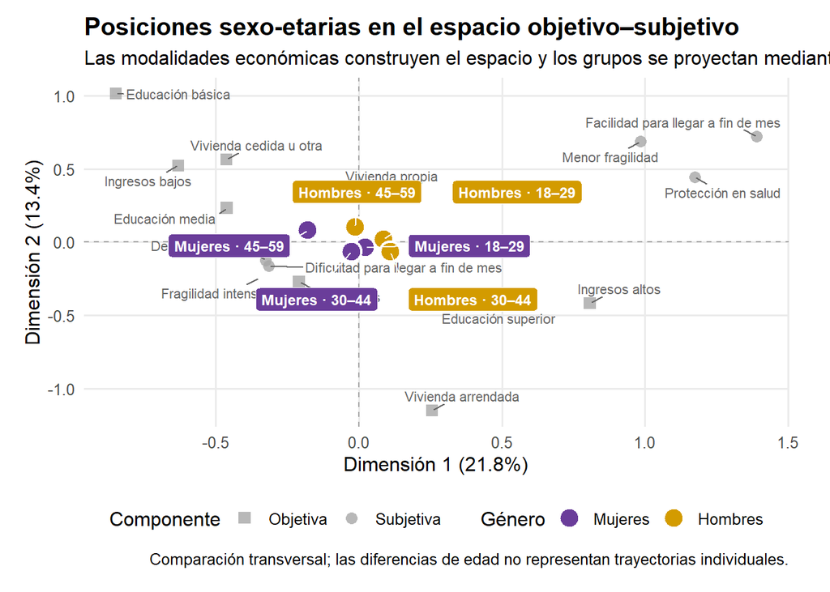

```r
figura_sexo_edad <- ggplot2::ggplot() +
  ggplot2::geom_hline(
    yintercept = 0,
    linetype = "dashed",
    linewidth = 0.4,
    color = "grey65"
  ) +
  ggplot2::geom_vline(
    xintercept = 0,
    linetype = "dashed",
    linewidth = 0.4,
    color = "grey65"
  ) +
  ggplot2::geom_point(
    data = tabla_modalidades_acm,
    ggplot2::aes(
      x = dimension_1,
      y = dimension_2,
      shape = componente
    ),
    color = "grey65",
    size = 3,
    alpha = 0.8
  ) +
  ggrepel::geom_text_repel(
    data = tabla_modalidades_acm,
    ggplot2::aes(
      x = dimension_1,
      y = dimension_2,
      label = modalidad
    ),
    color = "grey40",
    size = 2.9,
    max.overlaps = Inf,
    min.segment.length = 0,
    box.padding = 0.35,
    show.legend = FALSE
  ) +
  ggplot2::geom_point(
    data = tabla_posiciones_sexo_edad,
    ggplot2::aes(
      x = dimension_1,
      y = dimension_2,
      fill = genero
    ),
    shape = 21,
    size = 5.2,
    color = "white",
    stroke = 1.1
  ) +
  ggrepel::geom_label_repel(
    data = tabla_posiciones_sexo_edad,
    ggplot2::aes(
      x = dimension_1,
      y = dimension_2,
      label = grupo,
      fill = genero
    ),
    color = "white",
    fontface = "bold",
    size = 3.2,
    label.size = 0,
    max.overlaps = Inf,
    min.segment.length = 0,
    box.padding = 0.65,
    show.legend = FALSE
  ) +
  ggplot2::scale_fill_manual(
    values = paleta_genero,
    drop = FALSE
  ) +
  ggplot2::scale_shape_manual(
    values = c(
      "Objetiva" = 15,
      "Subjetiva" = 16
    )
  ) +
  ggplot2::labs(
    title = "Posiciones sexo-etarias en el espacio objetivo–subjetivo",
    subtitle = "Las modalidades económicas construyen el espacio y los grupos se proyectan mediante medias ponderadas",
    x = paste0(
      "Dimensión 1 (",
      round(
        tabla_inercia$porcentaje_inercia[1],
        1
      ),
      "%)"
    ),
    y = paste0(
      "Dimensión 2 (",
      round(
        tabla_inercia$porcentaje_inercia[2],
        1
      ),
      "%)"
    ),
    fill = "Género",
    shape = "Componente",
    caption = "Comparación transversal; las diferencias de edad no representan trayectorias individuales."
  ) +
  ggplot2::coord_cartesian(
    clip = "off"
  ) +
  ggplot2::theme_minimal(
    base_size = 12
  ) +
  ggplot2::theme(
    panel.grid.minor = ggplot2::element_blank(),
    plot.title = ggplot2::element_text(
      face = "bold",
      size = 15
    ),
    legend.position = "bottom",
    plot.margin = ggplot2::margin(
      10,
      25,
      15,
      15
    )
  )

figura_sexo_edad
```

# 22 Mapa con género y estructura parental

**Mostrar código**

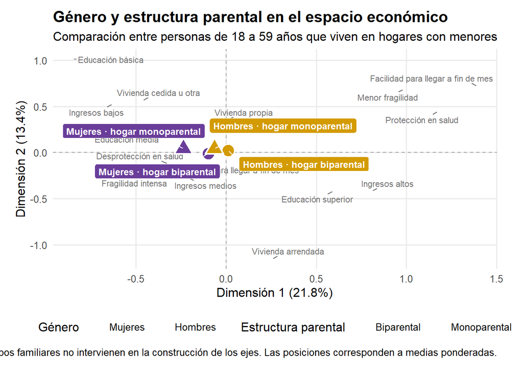

```r
figura_familias <- ggplot2::ggplot() +
  ggplot2::geom_hline(
    yintercept = 0,
    linetype = "dashed",
    linewidth = 0.4,
    color = "grey65"
  ) +
  ggplot2::geom_vline(
    xintercept = 0,
    linetype = "dashed",
    linewidth = 0.4,
    color = "grey65"
  ) +
  ggplot2::geom_point(
    data = tabla_modalidades_acm,
    ggplot2::aes(
      x = dimension_1,
      y = dimension_2,
      shape = componente
    ),
    color = "grey70",
    size = 3,
    alpha = 0.75
  ) +
  ggrepel::geom_text_repel(
    data = tabla_modalidades_acm,
    ggplot2::aes(
      x = dimension_1,
      y = dimension_2,
      label = modalidad
    ),
    color = "grey45",
    size = 2.9,
    max.overlaps = Inf,
    min.segment.length = 0,
    show.legend = FALSE
  ) +
  ggplot2::geom_point(
    data = tabla_posiciones_familiares,
    ggplot2::aes(
      x = dimension_1,
      y = dimension_2,
      fill = genero,
      shape = estructura_parental
    ),
    size = 5.5,
    color = "white",
    stroke = 1.1
  ) +
  ggrepel::geom_label_repel(
    data = tabla_posiciones_familiares,
    ggplot2::aes(
      x = dimension_1,
      y = dimension_2,
      label = grupo,
      fill = genero
    ),
    color = "white",
    fontface = "bold",
    size = 3.2,
    label.size = 0,
    max.overlaps = Inf,
    min.segment.length = 0,
    box.padding = 0.65,
    show.legend = FALSE
  ) +
  ggplot2::scale_fill_manual(
    values = paleta_genero,
    drop = FALSE
  ) +
  ggplot2::scale_shape_manual(
    values = c(
      "Biparental" = 21,
      "Monoparental" = 24
    ),
    drop = FALSE
  ) +
  ggplot2::labs(
    title = "Género y estructura parental en el espacio económico",
    subtitle = "Comparación entre personas de 18 a 59 años que viven en hogares con menores",
    x = paste0(
      "Dimensión 1 (",
      round(
        tabla_inercia$porcentaje_inercia[1],
        1
      ),
      "%)"
    ),
    y = paste0(
      "Dimensión 2 (",
      round(
        tabla_inercia$porcentaje_inercia[2],
        1
      ),
      "%)"
    ),
    fill = "Género",
    shape = "Estructura parental",
    caption = paste(
      "Los grupos familiares no intervienen en la construcción de los ejes.",
      "Las posiciones corresponden a medias ponderadas."
    )
  ) +
  ggplot2::coord_cartesian(
    clip = "off"
  ) +
  ggplot2::theme_minimal(
    base_size = 12
  ) +
  ggplot2::theme(
    panel.grid.minor = ggplot2::element_blank(),
    plot.title = ggplot2::element_text(
      face = "bold",
      size = 15
    ),
    legend.position = "bottom",
    legend.box = "horizontal",
    plot.margin = ggplot2::margin(
      10,
      25,
      15,
      15
    )
  )

figura_familias
```

# 23 Mapa con condición de actividad

**Mostrar código**

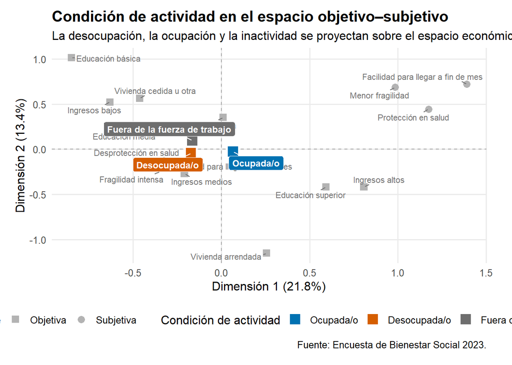

```r
figura_actividad <- ggplot2::ggplot() +
  ggplot2::geom_hline(
    yintercept = 0,
    linetype = "dashed",
    linewidth = 0.4,
    color = "grey65"
  ) +
  ggplot2::geom_vline(
    xintercept = 0,
    linetype = "dashed",
    linewidth = 0.4,
    color = "grey65"
  ) +
  ggplot2::geom_point(
    data = tabla_modalidades_acm,
    ggplot2::aes(
      x = dimension_1,
      y = dimension_2,
      shape = componente
    ),
    color = "grey70",
    size = 3
  ) +
  ggrepel::geom_text_repel(
    data = tabla_modalidades_acm,
    ggplot2::aes(
      x = dimension_1,
      y = dimension_2,
      label = modalidad
    ),
    color = "grey45",
    size = 2.9,
    max.overlaps = Inf,
    min.segment.length = 0,
    show.legend = FALSE
  ) +
  ggplot2::geom_point(
    data = tabla_posiciones_actividad,
    ggplot2::aes(
      x = dimension_1,
      y = dimension_2,
      fill = grupo
    ),
    shape = 22,
    size = 5.4,
    color = "white",
    stroke = 1.1
  ) +
  ggrepel::geom_label_repel(
    data = tabla_posiciones_actividad,
    ggplot2::aes(
      x = dimension_1,
      y = dimension_2,
      label = grupo,
      fill = grupo
    ),
    color = "white",
    fontface = "bold",
    size = 3.2,
    label.size = 0,
    max.overlaps = Inf,
    min.segment.length = 0,
    show.legend = FALSE
  ) +
  ggplot2::scale_fill_manual(
    values = paleta_actividad,
    drop = FALSE
  ) +
  ggplot2::scale_shape_manual(
    values = c(
      "Objetiva" = 15,
      "Subjetiva" = 16
    )
  ) +
  ggplot2::labs(
    title = "Condición de actividad en el espacio objetivo–subjetivo",
    subtitle = "La desocupación, la ocupación y la inactividad se proyectan sobre el espacio económico",
    x = paste0(
      "Dimensión 1 (",
      round(
        tabla_inercia$porcentaje_inercia[1],
        1
      ),
      "%)"
    ),
    y = paste0(
      "Dimensión 2 (",
      round(
        tabla_inercia$porcentaje_inercia[2],
        1
      ),
      "%)"
    ),
    fill = "Condición de actividad",
    shape = "Componente",
    caption = "Fuente: Encuesta de Bienestar Social 2023."
  ) +
  ggplot2::coord_cartesian(
    clip = "off"
  ) +
  ggplot2::theme_minimal(
    base_size = 12
  ) +
  ggplot2::theme(
    panel.grid.minor = ggplot2::element_blank(),
    plot.title = ggplot2::element_text(
      face = "bold",
      size = 15
    ),
    legend.position = "bottom",
    plot.margin = ggplot2::margin(
      10,
      25,
      15,
      15
    )
  )

figura_actividad
```

# 24 Comparación centrada en la dimensión 1

La primera dimensión suele ser la más clara para sintetizar el gradiente principal del ACM. Esta figura ordena los grupos familiares según su posición horizontal, sin exigir una interpretación fuerte de la segunda dimensión.

**Mostrar código**

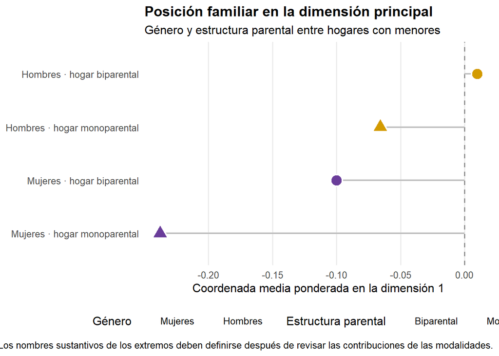

```r
figura_dimension_1_familias <- tabla_posiciones_familiares |>
  dplyr::mutate(
    grupo = forcats::fct_reorder(
      grupo,
      dimension_1
    )
  ) |>
  ggplot2::ggplot(
    ggplot2::aes(
      x = dimension_1,
      y = grupo,
      fill = genero,
      shape = estructura_parental
    )
  ) +
  ggplot2::geom_vline(
    xintercept = 0,
    linetype = "dashed",
    color = "grey55"
  ) +
  ggplot2::geom_segment(
    ggplot2::aes(
      x = 0,
      xend = dimension_1,
      yend = grupo
    ),
    color = "grey75",
    linewidth = 0.8
  ) +
  ggplot2::geom_point(
    size = 5,
    color = "white",
    stroke = 1.1
  ) +
  ggplot2::scale_fill_manual(
    values = paleta_genero,
    drop = FALSE
  ) +
  ggplot2::scale_shape_manual(
    values = c(
      "Biparental" = 21,
      "Monoparental" = 24
    ),
    drop = FALSE
  ) +
  ggplot2::labs(
    title = "Posición familiar en la dimensión principal",
    subtitle = "Género y estructura parental entre hogares con menores",
    x = "Coordenada media ponderada en la dimensión 1",
    y = NULL,
    fill = "Género",
    shape = "Estructura parental",
    caption = paste(
      "Los nombres sustantivos de los extremos deben definirse",
      "después de revisar las contribuciones de las modalidades."
    )
  ) +
  ggplot2::theme_minimal(
    base_size = 12
  ) +
  ggplot2::theme(
    panel.grid.minor = ggplot2::element_blank(),
    panel.grid.major.y = ggplot2::element_blank(),
    plot.title = ggplot2::element_text(
      face = "bold"
    ),
    legend.position = "bottom"
  )

figura_dimension_1_familias
```

# 25 Comparación sexo-etaria en la dimensión 1

**Mostrar código**

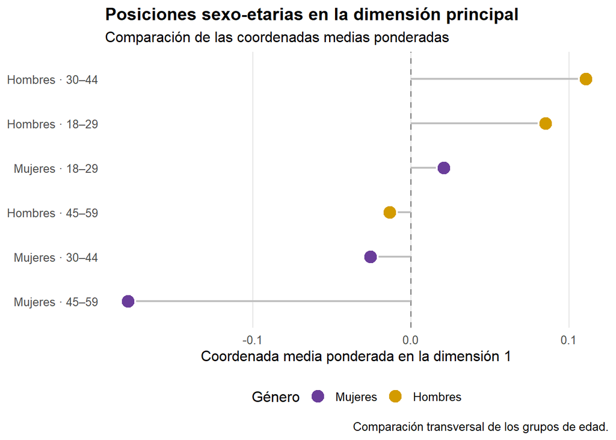

```r
figura_dimension_1_sexo_edad <- tabla_posiciones_sexo_edad |>
  dplyr::mutate(
    grupo = forcats::fct_reorder(
      grupo,
      dimension_1
    )
  ) |>
  ggplot2::ggplot(
    ggplot2::aes(
      x = dimension_1,
      y = grupo,
      fill = genero
    )
  ) +
  ggplot2::geom_vline(
    xintercept = 0,
    linetype = "dashed",
    color = "grey55"
  ) +
  ggplot2::geom_segment(
    ggplot2::aes(
      x = 0,
      xend = dimension_1,
      yend = grupo
    ),
    color = "grey75",
    linewidth = 0.8
  ) +
  ggplot2::geom_point(
    shape = 21,
    size = 5,
    color = "white",
    stroke = 1.1
  ) +
  ggplot2::scale_fill_manual(
    values = paleta_genero,
    drop = FALSE
  ) +
  ggplot2::labs(
    title = "Posiciones sexo-etarias en la dimensión principal",
    subtitle = "Comparación de las coordenadas medias ponderadas",
    x = "Coordenada media ponderada en la dimensión 1",
    y = NULL,
    fill = "Género",
    caption = "Comparación transversal de los grupos de edad."
  ) +
  ggplot2::theme_minimal(
    base_size = 12
  ) +
  ggplot2::theme(
    panel.grid.minor = ggplot2::element_blank(),
    panel.grid.major.y = ggplot2::element_blank(),
    plot.title = ggplot2::element_text(
      face = "bold"
    ),
    legend.position = "bottom"
  )

figura_dimension_1_sexo_edad
```

# 26 Resumen interpretativo automático

**Mostrar código**

```r
modalidades_extremo_positivo_d1 <- tabla_modalidades_acm |>
  dplyr::arrange(
    dplyr::desc(
      dimension_1
    )
  ) |>
  dplyr::slice_head(
    n = 5
  ) |>
  dplyr::select(
    modalidad,
    componente,
    dimension_1,
    contribucion_1
  )

modalidades_extremo_negativo_d1 <- tabla_modalidades_acm |>
  dplyr::arrange(
    dimension_1
  ) |>
  dplyr::slice_head(
    n = 5
  ) |>
  dplyr::select(
    modalidad,
    componente,
    dimension_1,
    contribucion_1
  )

modalidades_extremo_positivo_d2 <- tabla_modalidades_acm |>
  dplyr::arrange(
    dplyr::desc(
      dimension_2
    )
  ) |>
  dplyr::slice_head(
    n = 5
  ) |>
  dplyr::select(
    modalidad,
    componente,
    dimension_2,
    contribucion_2
  )

modalidades_extremo_negativo_d2 <- tabla_modalidades_acm |>
  dplyr::arrange(
    dimension_2
  ) |>
  dplyr::slice_head(
    n = 5
  ) |>
  dplyr::select(
    modalidad,
    componente,
    dimension_2,
    contribucion_2
  )
```

**Mostrar código**

```r
knitr::kable(
  modalidades_extremo_positivo_d1 |>
    dplyr::mutate(
      dplyr::across(
        where(
          is.numeric
        ),
        ~ round(
          .x,
          3
        )
      )
    ),
  caption = "Modalidades ubicadas en el extremo positivo de la dimensión 1"
)
```

Modalidades ubicadas en el extremo positivo de la dimensión 1

| modalidad | componente | dimension_1 | contribucion_1 |
| --- | --- | --- | --- |
| Facilidad para llegar a fin de mes | Subjetiva | 1.390 | 18.203 |
| Protección en salud | Subjetiva | 1.174 | 15.283 |
| Menor fragilidad | Subjetiva | 0.983 | 12.929 |
| Ingresos altos | Objetiva | 0.807 | 12.523 |
| Educación superior | Objetiva | 0.592 | 8.479 |

**Mostrar código**

```r
knitr::kable(
  modalidades_extremo_negativo_d1 |>
    dplyr::mutate(
      dplyr::across(
        where(
          is.numeric
        ),
        ~ round(
          .x,
          3
        )
      )
    ),
  caption = "Modalidades ubicadas en el extremo negativo de la dimensión 1"
)
```

Modalidades ubicadas en el extremo negativo de la dimensión 1

| modalidad | componente | dimension_1 | contribucion_1 |
| --- | --- | --- | --- |
| Educación básica | Objetiva | -0.850 | 3.563 |
| Ingresos bajos | Objetiva | -0.632 | 8.362 |
| Vivienda cedida u otra | Objetiva | -0.464 | 1.695 |
| Educación media | Objetiva | -0.462 | 4.683 |
| Fragilidad intensa | No identificado | -0.349 | 4.587 |

**Mostrar código**

```r
knitr::kable(
  modalidades_extremo_positivo_d2 |>
    dplyr::mutate(
      dplyr::across(
        where(
          is.numeric
        ),
        ~ round(
          .x,
          3
        )
      )
    ),
  caption = "Modalidades ubicadas en el extremo positivo de la dimensión 2"
)
```

Modalidades ubicadas en el extremo positivo de la dimensión 2

| modalidad | componente | dimension_2 | contribucion_2 |
| --- | --- | --- | --- |
| Educación básica | Objetiva | 1.015 | 8.259 |
| Facilidad para llegar a fin de mes | Subjetiva | 0.723 | 8.002 |
| Menor fragilidad | Subjetiva | 0.687 | 10.256 |
| Vivienda cedida u otra | Objetiva | 0.566 | 4.109 |
| Ingresos bajos | Objetiva | 0.524 | 9.345 |

**Mostrar código**

```r
knitr::kable(
  modalidades_extremo_negativo_d2 |>
    dplyr::mutate(
      dplyr::across(
        where(
          is.numeric
        ),
        ~ round(
          .x,
          3
        )
      )
    ),
  caption = "Modalidades ubicadas en el extremo negativo de la dimensión 2"
)
```

Modalidades ubicadas en el extremo negativo de la dimensión 2

| modalidad | componente | dimension_2 | contribucion_2 |
| --- | --- | --- | --- |
| Vivienda arrendada | Objetiva | -1.152 | 28.310 |
| Educación superior | Objetiva | -0.419 | 6.894 |
| Ingresos altos | Objetiva | -0.418 | 5.445 |
| Ingresos medios | Objetiva | -0.271 | 1.299 |
| Fragilidad intensa | No identificado | -0.244 | 3.639 |

# 27 Exportación de figuras

**Mostrar código**

```r
figuras_exportar <- list(
  "05_inercia_acm_objetivo_subjetivo" =
    figura_inercia,

  "05_mapa_modalidades_objetivo_subjetivo" =
    figura_modalidades,

  "05_mapa_grupos_sexo_edad" =
    figura_sexo_edad,

  "05_mapa_genero_estructura_parental" =
    figura_familias,

  "05_mapa_condicion_actividad" =
    figura_actividad,

  "05_dimension_1_familias" =
    figura_dimension_1_familias,

  "05_dimension_1_sexo_edad" =
    figura_dimension_1_sexo_edad
)
```

**Mostrar código**

```r
for (
  nombre_figura in
  names(
    figuras_exportar
  )
) {

  grafico_actual <-
    figuras_exportar[[nombre_figura]]

  ggplot2::ggsave(
    filename = file.path(
      ruta_figuras,
      paste0(
        nombre_figura,
        ".png"
      )
    ),
    plot = grafico_actual,
    width = 11,
    height = 8,
    units = "in",
    dpi = 300
  )

  ggplot2::ggsave(
    filename = file.path(
      ruta_figuras,
      paste0(
        nombre_figura,
        ".svg"
      )
    ),
    plot = grafico_actual,
    width = 11,
    height = 8,
    units = "in"
  )
}
```

# 28 Exportación de tablas CSV

**Mostrar código**

```r
tablas_csv <- list(
  "05_cobertura_variables_activas.csv" =
    tabla_cobertura_activas,

  "05_muestra_acm.csv" =
    resumen_muestra_acm,

  "05_distribucion_modalidades.csv" =
    tabla_distribucion_modalidades,

  "05_inercia.csv" =
    tabla_inercia,

  "05_modalidades_coordenadas_contribuciones.csv" =
    tabla_contribuciones_principales,

  "05_posiciones_sexo_edad.csv" =
    tabla_posiciones_sexo_edad,

  "05_posiciones_familiares.csv" =
    tabla_posiciones_familiares,

  "05_posiciones_actividad.csv" =
    tabla_posiciones_actividad,

  "05_posiciones_complementarias.csv" =
    tabla_posiciones_complementarias,

  "05_extremo_positivo_dimension_1.csv" =
    modalidades_extremo_positivo_d1,

  "05_extremo_negativo_dimension_1.csv" =
    modalidades_extremo_negativo_d1,

  "05_extremo_positivo_dimension_2.csv" =
    modalidades_extremo_positivo_d2,

  "05_extremo_negativo_dimension_2.csv" =
    modalidades_extremo_negativo_d2
)
```

**Mostrar código**

```r
purrr::iwalk(
  tablas_csv,
  function(
      tabla,
      nombre_archivo
  ) {

    readr::write_csv(
      tabla,
      file.path(
        ruta_tablas,
        nombre_archivo
      ),
      na = ""
    )
  }
)
```

# 29 Libro Excel consolidado

**Mostrar código**

```r
archivo_excel <- file.path(
  ruta_tablas,
  "05_acm_objetivo_subjetivo.xlsx"
)

tablas_excel <- list(
  "Muestra" =
    resumen_muestra_acm,

  "Cobertura activas" =
    tabla_cobertura_activas,

  "Distribución modalidades" =
    tabla_distribucion_modalidades,

  "Inercia" =
    tabla_inercia,

  "Modalidades ACM" =
    tabla_contribuciones_principales,

  "Sexo y edad" =
    tabla_posiciones_sexo_edad,

  "Estructura familiar" =
    tabla_posiciones_familiares,

  "Actividad" =
    tabla_posiciones_actividad,

  "Complementarias" =
    tabla_posiciones_complementarias,

  "Extremo positivo D1" =
    modalidades_extremo_positivo_d1,

  "Extremo negativo D1" =
    modalidades_extremo_negativo_d1,

  "Extremo positivo D2" =
    modalidades_extremo_positivo_d2,

  "Extremo negativo D2" =
    modalidades_extremo_negativo_d2
)
```

**Mostrar código**

```r
libro_salida <- openxlsx::createWorkbook()

estilo_encabezado <- openxlsx::createStyle(
  textDecoration = "bold",
  halign = "center",
  valign = "center",
  wrapText = TRUE
)

for (
  nombre_hoja in
  names(
    tablas_excel
  )
) {

  tabla_actual <-
    tablas_excel[[nombre_hoja]]

  nombre_hoja_seguro <- substr(
    nombre_hoja,
    1,
    31
  )

  openxlsx::addWorksheet(
    libro_salida,
    nombre_hoja_seguro
  )

  openxlsx::writeDataTable(
    libro_salida,
    sheet = nombre_hoja_seguro,
    x = tabla_actual
  )

  openxlsx::freezePane(
    libro_salida,
    sheet = nombre_hoja_seguro,
    firstRow = TRUE
  )

  if (
    ncol(
      tabla_actual
    ) > 0
  ) {

    openxlsx::addStyle(
      libro_salida,
      sheet = nombre_hoja_seguro,
      style = estilo_encabezado,
      rows = 1,
      cols = seq_len(
        ncol(
          tabla_actual
        )
      ),
      gridExpand = TRUE
    )

    openxlsx::setColWidths(
      libro_salida,
      sheet = nombre_hoja_seguro,
      cols = seq_len(
        ncol(
          tabla_actual
        )
      ),
      widths = "auto"
    )
  }
}

openxlsx::saveWorkbook(
  libro_salida,
  file = archivo_excel,
  overwrite = TRUE
)
```

# 30 Exportación de objetos reutilizables

**Mostrar código**

```r
saveRDS(
  base_acm,
  file.path(
    ruta_objetos,
    "05_base_acm_objetivo_subjetivo.rds"
  )
)

saveRDS(
  base_coordenadas_acm,
  file.path(
    ruta_objetos,
    "05_base_con_coordenadas_individuales.rds"
  )
)

saveRDS(
  tabla_modalidades_acm,
  file.path(
    ruta_objetos,
    "05_modalidades_acm.rds"
  )
)

saveRDS(
  tabla_posiciones_sexo_edad,
  file.path(
    ruta_objetos,
    "05_posiciones_sexo_edad.rds"
  )
)

saveRDS(
  tabla_posiciones_familiares,
  file.path(
    ruta_objetos,
    "05_posiciones_familiares.rds"
  )
)

saveRDS(
  tabla_posiciones_actividad,
  file.path(
    ruta_objetos,
    "05_posiciones_actividad.rds"
  )
)
```

# 31 Resumen automático

**Mostrar código**

```r
cat(
  "Casos en la base de origen:",
  nrow(
    base_preparada
  ),
  "\n"
)
```

```
Casos en la base de origen: 7612
```

**Mostrar código**

```r
cat(
  "Casos utilizados en el ACM:",
  nrow(
    base_acm
  ),
  "\n"
)
```

```
Casos utilizados en el ACM: 7500
```

**Mostrar código**

```r
cat(
  "Porcentaje retenido:",
  round(
    100 *
      nrow(
        base_acm
      ) /
      nrow(
        base_preparada
      ),
    1
  ),
  "%.\n"
)
```

```
Porcentaje retenido: 98.5 %.
```

**Mostrar código**

```r
cat(
  "Inercia de la dimensión 1:",
  round(
    tabla_inercia$porcentaje_inercia[1],
    1
  ),
  "%.\n"
)
```

```
Inercia de la dimensión 1: 21.8 %.
```

**Mostrar código**

```r
cat(
  "Inercia de la dimensión 2:",
  round(
    tabla_inercia$porcentaje_inercia[2],
    1
  ),
  "%.\n"
)
```

```
Inercia de la dimensión 2: 13.4 %.
```

**Mostrar código**

```r
cat(
  "Inercia acumulada de las dos primeras dimensiones:",
  round(
    tabla_inercia$porcentaje_acumulado[2],
    1
  ),
  "%.\n"
)
```

```
Inercia acumulada de las dos primeras dimensiones: 35.2 %.
```

**Mostrar código**

```r
cat(
  "Libro Excel:",
  normalizePath(
    archivo_excel,
    winslash = "/",
    mustWork = FALSE
  ),
  "\n"
)
```

```
Libro Excel: C:/Users/PC/OneDrive/Postgrados/OBDE/Taller Med Obj Subj/outputs/05_acm_objetivo_subjetivo/tablas/05_acm_objetivo_subjetivo.xlsx
```

# 32 Información de la sesión

**Mostrar código**